# A Few Other Things for Running Regressions In R

This week, you should focus on wrapping up your projects and studying for the exam, but I wanted to show you a few last commands in R that are useful for running regressions and then diagnosing if there are any potential problems. We’ve discussed many of these in class, but I wanted to give some examples here.

The data set we are using here includes variables relating to unionization and state economic and political factors in 2018. Much of the data comes from Laura Bucci’s [data set](https://dataverse.unc.edu/dataset.xhtml?persistentId=doi:10.15139/S3/L95PUM), among other sources. If you want to use this data set for something outside this class, please consult with me about the exact sources for each variable.

# Variables

The variables in this dataset are as follows:

- State Name
- State Abbreviation
- Percentage of People in the State in a Union in 2018
- Percentage of State Population that was non-white in 2018
- Percentage of State’s Economy that was based in Manufacturing in 2018
- Individual Average Disposable Income in 2018
- State Minimum Wage in 2018
- State Poverty Rate in 2018
- State GDP in 2018
- Median Age in 2018
- Percentage of People in the State with a High School Degree in 2018
- Percentage of People in the State with a College Degree in 2018
- Unemployment in 2018
- Dummy variable for whether the state has a [right-to-work law](https://en.wikipedia.org/wiki/Right-to-work_law).
- Percentage of the Vote Received by Donald Trump in 2016
- Dummy variable for whether state has a GOP Governor

# Multiple Regression in R

You want to predict a state’s percentage union in 2018 and think that important factors include whether the state has a right-to-work law and how Republican leaning it is, based on the Trump 2016 vote. You also decide to control for percent manufacturing and percentage of people with a high school degree. In R, you can do that using the below code.

First, you need to load your data into R.

```r
#First, load the data
library(readxl)
UnionData<- read_excel("D:/USB20FD - Copy/STA101Summer2/StateUnionEconomicData.xlsx")

#Then, you are ready to run the model
UnionizationModel<- lm(UnionData$UnionMember~ UnionData$RTW+ UnionData$Trump2016 + UnionData$Manufacturing+ UnionData$HS)

#Then, look at your model
summary(UnionizationModel)
```

```
##
## Call:
## lm(formula = UnionData$UnionMember ~ UnionData$RTW + UnionData$Trump2016 +
##     UnionData$Manufacturing + UnionData$HS)
##
## Residuals:
##     Min      1Q  Median      3Q     Max
## -6.7425 -2.1816 -0.6278  1.1573  7.9344
##
## Coefficients:
##                         Estimate Std. Error t value Pr(>|t|)
## (Intercept)              5.98090   18.64815   0.321  0.74990
## UnionData$RTW           -5.47906    1.56609  -3.499  0.00107 **
## UnionData$Trump2016     -0.10976    0.06658  -1.648  0.10622
## UnionData$Manufacturing -3.36138   10.54911  -0.319  0.75147
## UnionData$HS             0.14735    0.21174   0.696  0.49005
## ---
## Signif. codes:  0 '***' 0.001 '**' 0.01 '*' 0.05 '.' 0.1 ' ' 1
##
## Residual standard error: 3.528 on 45 degrees of freedom
## Multiple R-squared:  0.5672, Adjusted R-squared:  0.5288
## F-statistic: 14.74 on 4 and 45 DF,  p-value: 9.008e-08
```

What do you find after running the model? Think about how you might interpret this output.

# Multicollinearity in R

After running a model, one of the first things you want to do is look for multicollinearity. When your independent variables correlate strongly with one another, it can wreak havoc on your model.

One way to check for multicollinearity is by looking at the [variance inflation factor, or VIF](https://en.wikipedia.org/wiki/Variance_inflation_factor).

To do this, first you should load the car package.

`install.packages("car")`

Then, you are ready to test for multicollinearity.

```r
library(car)
car::vif(UnionizationModel)
```

```
##           UnionData$RTW     UnionData$Trump2016 UnionData$Manufacturing
##                2.447939                2.093314                1.186003
##            UnionData$HS
##                1.221201
```

Do our VIFs here meet the level we discussed in class (> 10, although this is not a set standard) to worry about multicollinearity? Why do you think this is the case?

# Plotting for Normality

After running a model, you will want to look for normality in the residuals. You can do this by either looking at a historgram or a scatterplot of the absolute residuals plotted against the dependent variable.

First, we do the histogram. Do the residuals appear to be normal?

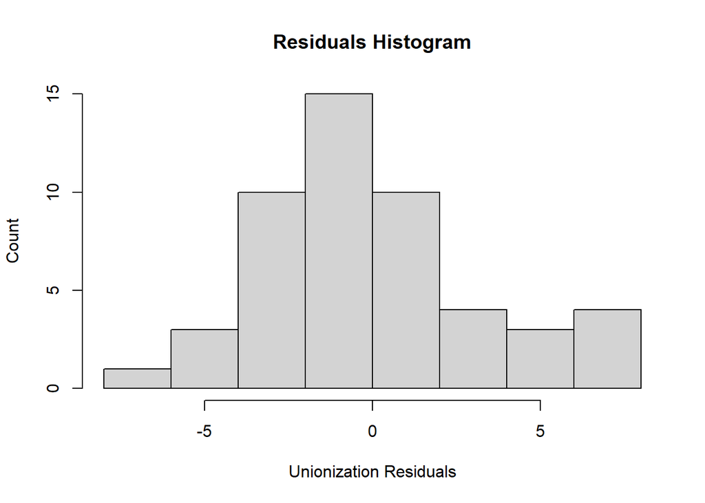

```r
unionresid<-resid(UnionizationModel)
hist(unionresid, xlab=
       "Unionization Residuals", ylab="Count", main=
       "Residuals Histogram")
```

Then, make a scatter plot of the absolute residuals and the dependent variable and include a line of best fit. Does there appear to be a trend?

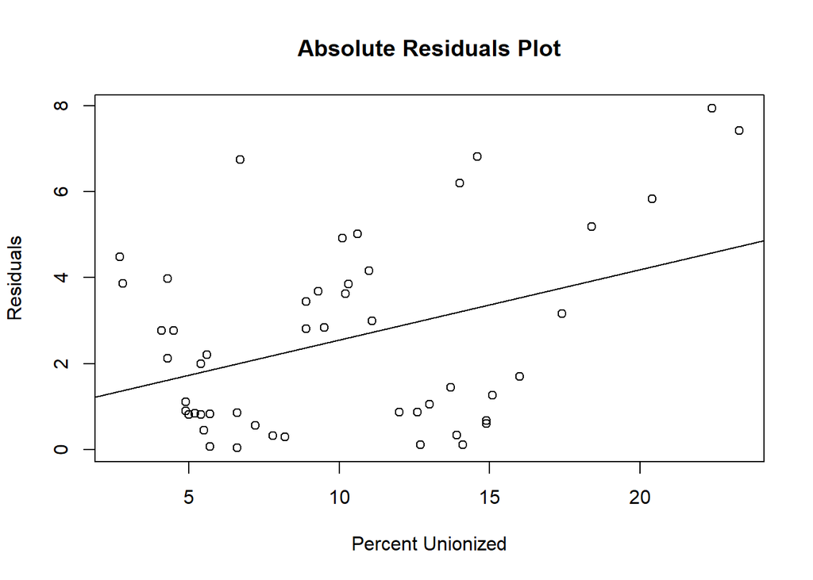

```r
absresid<-abs(unionresid)
plot(UnionData$UnionMember, absresid, xlab=
       "Percent Unionized", ylab="Residuals", main=
       "Absolute Residuals Plot")
box()
abline(lm(absresid~UnionData$UnionMember))
```

# On Your Own

On your own, trying adding in some other variables or running a model with a totally different dependent variable. Find the VIF and plot the residuals. Think about how you might interpret the output.

# Logistic Regression in R

In class on Tuesday, we will discuss another type of regression: logistic regression. Logistic regression is a common type of regression used with dichotomous dependent variables (i.e., dummy variables). (If you have a dichotomous dependent variable in your paper, it is okay if you are using an OLS, but it might be a good idea to also fit it as a logit and make a note of whether your results changed.)

We want to predict if a state had a right-to-work law and we think that its political leanings (in terms of Trump vote) and its percent manufacturing were most important at predicting whether it had such a law. We also want to control for education and race.

You can make logistic regression with the [glm](https://www.statmethods.net/advstats/glm.html) function. For a logit, the last part of the code you will write here is family=binomial. You would specify a different command here for other models, but you should copy this if you are running another logit.

[output not shown]

As we will discuss on Tuesday, coefficients from logits cannot be interpreted the same way as for OLS regression models, but the output here still tells you the direction of the relationship and statistical significance.

# Predicted Probability Plots

There are several ways to interpret the output of logistic regression models, but my personal preference are predicted probabilities. You can convert the logit coefficients (which are expressed in log odds) to predicted probabilities of “success” (i.e., the dependent variable is equal to 1) at various levels of the other variables.

Using the [effects](https://data.library.virginia.edu/visualizing-the-effects-of-logistic-regression/) package in R, you can plot predicted probabilities at various levels of the independent variables. Below I plot the predicted probability of a state being right-to-work as you go from the minimum value of an independent variable to the maximum value of that variable. Please note that for each prediction, the other variables are held at their mean value.

(Note: the tick marks on the bottom of each plot represent actual values of that variable. In some cases, you get a prediction for a value for a variable that does not actually exist in the data set. Beware of extrapolation.)

```r
library(effects)
```

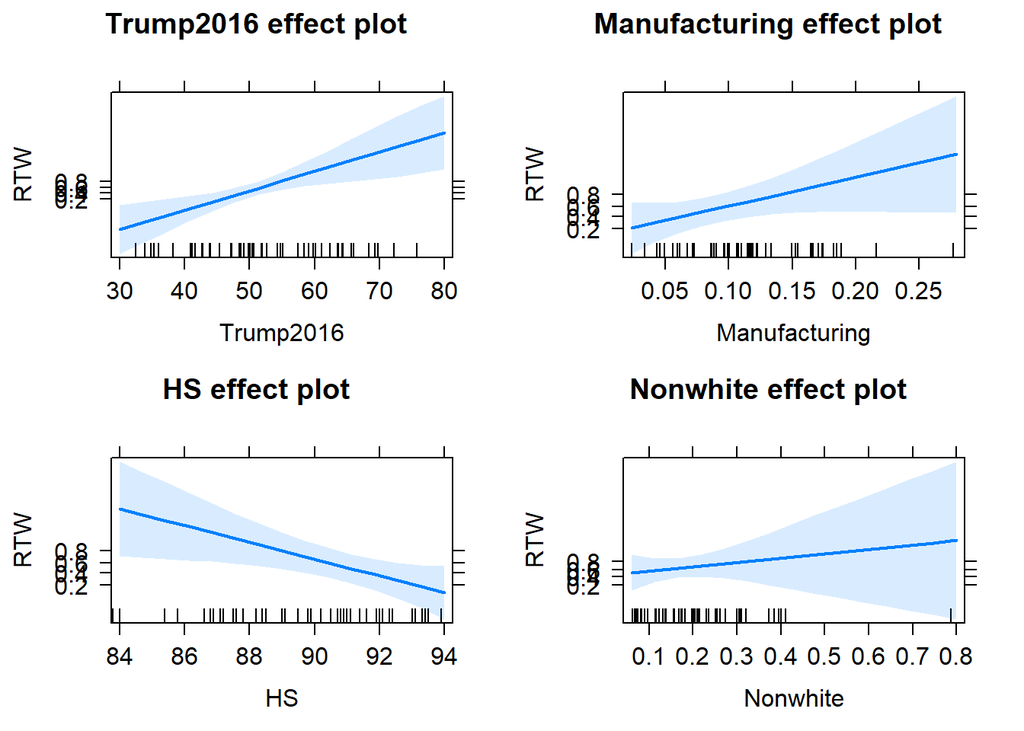

```r
logit1<-glm(RTW~ Trump2016+ Manufacturing+ HS + Nonwhite, data=UnionData ,family=binomial)

plot(allEffects(logit1))
```

Notice here that the y-axis includes some unrealistic values and the labels are kind of scrunched and that there are plots for all four variables here. Using the selection command, you can pick which variable you would like to plot and using ylim, you can change the y-axis scale. Here, I plot the second variable (percent manufacturing) over a narrower scale.

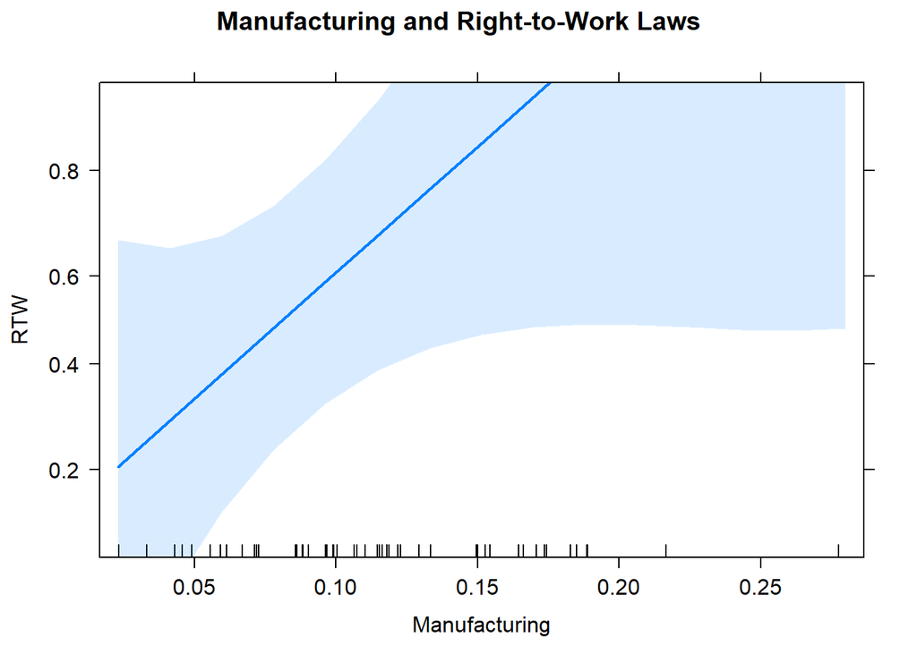

```r
plot(allEffects(logit1), selection=2, ylim = qlogis(c(.1,.9)), main="Manufacturing and Right-to-Work Laws")
```

# Wrapping Things Up

Now, try removing or adding other variables to the logistic regression model and practice plotting its marginal effects.

There is nothing to turn in, but I wanted to give you some practice on other useful things in R. While you won’t have to specifically use R for the exam, the broad concepts from this lab may appear in some form there.